# Exploratory data analysis

```python
import numpy as np
import pandas as pd
import matplotlib.pyplot as plt
import seaborn as sb
%matplotlib inline
```

```python
df = pd.read_csv('prosperLoanData.csv')
```

```python
df.head()
```

|  | ListingKey | ListingNumber | ListingCreationDate | CreditGrade | Term | LoanStatus | ClosedDate | BorrowerAPR | BorrowerRate | LenderYield | ... | LP_ServiceFees | LP_CollectionFees | LP_GrossPrincipalLoss | LP_NetPrincipalLoss | LP_NonPrincipalRecoverypayments | PercentFunded | Recommendations | InvestmentFromFriendsCount | InvestmentFromFriendsAmount | Investors |
| --- | --- | --- | --- | --- | --- | --- | --- | --- | --- | --- | --- | --- | --- | --- | --- | --- | --- | --- | --- | --- | --- |
| 0 | 1021339766868145413AB3B | 193129 | 2007-08-26 19:09:29.263000000 | C | 36 | Completed | 2009-08-14 00:00:00 | 0.16516 | 0.1580 | 0.1380 | ... | -133.18 | 0.0 | 0.0 | 0.0 | 0.0 | 1.0 | 0 | 0 | 0.0 | 258 |
| 1 | 10273602499503308B223C1 | 1209647 | 2014-02-27 08:28:07.900000000 | NaN | 36 | Current | NaN | 0.12016 | 0.0920 | 0.0820 | ... | 0.00 | 0.0 | 0.0 | 0.0 | 0.0 | 1.0 | 0 | 0 | 0.0 | 1 |
| 2 | 0EE9337825851032864889A | 81716 | 2007-01-05 15:00:47.090000000 | HR | 36 | Completed | 2009-12-17 00:00:00 | 0.28269 | 0.2750 | 0.2400 | ... | -24.20 | 0.0 | 0.0 | 0.0 | 0.0 | 1.0 | 0 | 0 | 0.0 | 41 |
| 3 | 0EF5356002482715299901A | 658116 | 2012-10-22 11:02:35.010000000 | NaN | 36 | Current | NaN | 0.12528 | 0.0974 | 0.0874 | ... | -108.01 | 0.0 | 0.0 | 0.0 | 0.0 | 1.0 | 0 | 0 | 0.0 | 158 |
| 4 | 0F023589499656230C5E3E2 | 909464 | 2013-09-14 18:38:39.097000000 | NaN | 36 | Current | NaN | 0.24614 | 0.2085 | 0.1985 | ... | -60.27 | 0.0 | 0.0 | 0.0 | 0.0 | 1.0 | 0 | 0 | 0.0 | 20 |

5 rows × 81 columns

```python
df.info()
```

```
<class 'pandas.core.frame.DataFrame'>
RangeIndex: 113937 entries, 0 to 113936
Data columns (total 81 columns):
 #   Column                               Non-Null Count   Dtype
---  ------                               --------------   -----
 0   ListingKey                           113937 non-null  object
 1   ListingNumber                        113937 non-null  int64
 2   ListingCreationDate                  113937 non-null  object
 3   CreditGrade                          28953 non-null   object
 4   Term                                 113937 non-null  int64
 5   LoanStatus                           113937 non-null  object
 6   ClosedDate                           55089 non-null   object
 7   BorrowerAPR                          113912 non-null  float64
 8   BorrowerRate                         113937 non-null  float64
 9   LenderYield                          113937 non-null  float64
```

[output cut: 73 more lines]

```python
df.shape
```

```
(113937, 81)
```

# Structure of the dataset

This dataset contains 81 columns and 113937 rows. I will extract some key columns for this analysis. Ths most intersting column for me is the APR and what are the important factors for determining the APR of each loan.

# Interested Columns

```python
df.columns
```

```
Index(['ListingKey', 'ListingNumber', 'ListingCreationDate', 'CreditGrade',
       'Term', 'LoanStatus', 'ClosedDate', 'BorrowerAPR', 'BorrowerRate',
       'LenderYield', 'EstimatedEffectiveYield', 'EstimatedLoss',
       'EstimatedReturn', 'ProsperRating (numeric)', 'ProsperRating (Alpha)',
       'ProsperScore', 'ListingCategory (numeric)', 'BorrowerState',
       'Occupation', 'EmploymentStatus', 'EmploymentStatusDuration',
       'IsBorrowerHomeowner', 'CurrentlyInGroup', 'GroupKey',
       'DateCreditPulled', 'CreditScoreRangeLower', 'CreditScoreRangeUpper',
       'FirstRecordedCreditLine', 'CurrentCreditLines', 'OpenCreditLines',
       'TotalCreditLinespast7years', 'OpenRevolvingAccounts',
       'OpenRevolvingMonthlyPayment', 'InquiriesLast6Months', 'TotalInquiries',
       'CurrentDelinquencies', 'AmountDelinquent', 'DelinquenciesLast7Years',
       'PublicRecordsLast10Years', 'PublicRecordsLast12Months',
       'RevolvingCreditBalance', 'BankcardUtilization',
       'AvailableBankcardCredit', 'TotalTrades',
       'TradesNeverDelinquent (percentage)', 'TradesOpenedLast6Months',
       'DebtToIncomeRatio', 'IncomeRange', 'IncomeVerifiable',
       'StatedMonthlyIncome', 'LoanKey', 'TotalProsperLoans',
       'TotalProsperPaymentsBilled', 'OnTimeProsperPayments',
       'ProsperPaymentsLessThanOneMonthLate',
       'ProsperPaymentsOneMonthPlusLate', 'ProsperPrincipalBorrowed',
       'ProsperPrincipalOutstanding', 'ScorexChangeAtTimeOfListing',
       'LoanCurrentDaysDelinquent', 'LoanFirstDefaultedCycleNumber',
       'LoanMonthsSinceOrigination', 'LoanNumber', 'LoanOriginalAmount',
       'LoanOriginationDate', 'LoanOriginationQuarter', 'MemberKey',
       'MonthlyLoanPayment', 'LP_CustomerPayments',
       'LP_CustomerPrincipalPayments', 'LP_InterestandFees', 'LP_ServiceFees',
       'LP_CollectionFees', 'LP_GrossPrincipalLoss', 'LP_NetPrincipalLoss',
       'LP_NonPrincipalRecoverypayments', 'PercentFunded', 'Recommendations',
       'InvestmentFromFriendsCount', 'InvestmentFromFriendsAmount',
       'Investors'],
      dtype='object')
```

**Columns of interest**: 'CreditGrade', 'Term', 'BorrowerAPR', 'ProsperScore', 'ListingCategory (numeric)', 'EmploymentStatus', 'EmploymentStatusDuration', 'CreditScoreRangeLower', 'CreditScoreRangeUpper', 'StatedMonthlyIncome', 'LoanOriginalAmount'

```python
# create new dataframe that contains only columns needed for analysis
df_sub = df[['CreditGrade', 'Term', 'BorrowerAPR', 'ProsperScore', 'ListingCategory (numeric)', \
             'EmploymentStatus', 'EmploymentStatusDuration', 'CreditScoreRangeLower', \
             'CreditScoreRangeUpper', 'StatedMonthlyIncome', 'LoanOriginalAmount']]
```

```python
df_sub.info()
```

```
<class 'pandas.core.frame.DataFrame'>
RangeIndex: 113937 entries, 0 to 113936
Data columns (total 11 columns):
 #   Column                     Non-Null Count   Dtype
---  ------                     --------------   -----
 0   CreditGrade                28953 non-null   object
 1   Term                       113937 non-null  int64
 2   BorrowerAPR                113912 non-null  float64
 3   ProsperScore               84853 non-null   float64
 4   ListingCategory (numeric)  113937 non-null  int64
 5   EmploymentStatus           111682 non-null  object
 6   EmploymentStatusDuration   106312 non-null  float64
 7   CreditScoreRangeLower      113346 non-null  float64
 8   CreditScoreRangeUpper      113346 non-null  float64
 9   StatedMonthlyIncome        113937 non-null  float64
 10  LoanOriginalAmount         113937 non-null  int64
dtypes: float64(6), int64(3), object(2)
memory usage: 9.6+ MB
```

```python
df_sub.head()
```

|  | CreditGrade | Term | BorrowerAPR | ProsperScore | ListingCategory (numeric) | EmploymentStatus | EmploymentStatusDuration | CreditScoreRangeLower | CreditScoreRangeUpper | StatedMonthlyIncome | LoanOriginalAmount |
| --- | --- | --- | --- | --- | --- | --- | --- | --- | --- | --- | --- |
| 0 | C | 36 | 0.16516 | NaN | 0 | Self-employed | 2.0 | 640.0 | 659.0 | 3083.333333 | 9425 |
| 1 | NaN | 36 | 0.12016 | 7.0 | 2 | Employed | 44.0 | 680.0 | 699.0 | 6125.000000 | 10000 |
| 2 | HR | 36 | 0.28269 | NaN | 0 | Not available | NaN | 480.0 | 499.0 | 2083.333333 | 3001 |
| 3 | NaN | 36 | 0.12528 | 9.0 | 16 | Employed | 113.0 | 800.0 | 819.0 | 2875.000000 | 10000 |
| 4 | NaN | 36 | 0.24614 | 4.0 | 2 | Employed | 44.0 | 680.0 | 699.0 | 9583.333333 | 15000 |

# Data Exploration Analysis

## Univariate Exploration

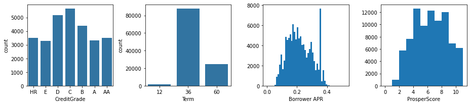

```python
credit_grade_order = ['HR','E','D','C','B','A','AA']
# create bin size for each variable
apr_bin = np.arange(0, df_sub.BorrowerAPR.max() + 0.01, 0.01)
ProsperScore_bin = np.arange(0, df_sub.ProsperScore.max() + 1, 1)

base_color = sb.color_palette()[0]
fig, ax = plt.subplots(1, 4, figsize=(13, 3))
sb.countplot(data = df_sub, x='CreditGrade', ax=ax[0], color=base_color, order = credit_grade_order);
sb.countplot(data = df_sub, x='Term', ax=ax[1], color=base_color);
ax[2].hist(data=df_sub, x='BorrowerAPR', bins=apr_bin);
ax[2].set_xlabel('Borrower APR');
ax[3].hist(data=df_sub, x='ProsperScore', bins=ProsperScore_bin);
ax[3].set_xlabel('ProsperScore');
ax[3].set_xticks([0, 2, 4, 6, 8, 10])
fig.tight_layout();
```

**CreditGrade**: Unimodal distribution with most people towards middle of the credit grade (C).  
**Term**: Most loans are on 36 months term followed by 60 months and least people took out 12 month loan  
**Borrower APR**: Unimodal distribution with most APRs around 0.2, but a significant number of loans with about 0.38 APR.  
**ProsperScore**: Unimodal distribution with most people towards middle of the prosper score spectrum (medium risk).

```python
df_sub.StatedMonthlyIncome.describe()
```

```
count    1.139370e+05
mean     5.608026e+03
std      7.478497e+03
min      0.000000e+00
25%      3.200333e+03
50%      4.666667e+03
75%      6.825000e+03
max      1.750003e+06
Name: StatedMonthlyIncome, dtype: float64
```

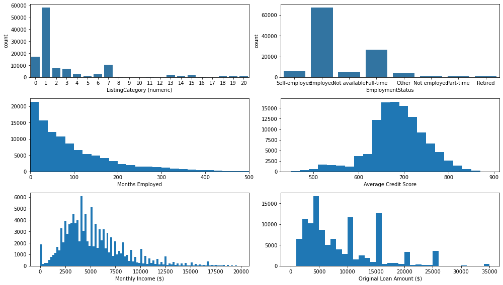

```python
base_color = sb.color_palette()[0]

# Combine CreditScoreRangeLower and CreditScoreRangeUpper to create avg credit score variable
df_sub['AvgCreditScore'] = (df_sub.CreditScoreRangeLower + df_sub.CreditScoreRangeUpper) / 2

# create bin size for each variable
emp_duration_bin = np.arange(0, df_sub.EmploymentStatusDuration.max() + 20, 20)
credit_score_bin = np.arange(450, df_sub.AvgCreditScore.max() + 5, 20)
income_bin = np.arange(0, 20000, 200)
loan_amt_bin = np.arange(0, df_sub.LoanOriginalAmount.max() + 1000, 1000)


fig, ax = plt.subplots(3, 2, figsize=(14, 8));
sb.countplot(data=df_sub, x='ListingCategory (numeric)', ax=ax[0, 0], color=base_color);
sb.countplot(data=df_sub, x='EmploymentStatus', ax=ax[0, 1], color=base_color);
ax[1, 0].hist(data=df_sub, x='EmploymentStatusDuration', bins=emp_duration_bin);
ax[1, 0].set_xlim(0, 500);
ax[1, 0].set_xlabel('Months Employed');
ax[1, 1].hist(data=df_sub, x='AvgCreditScore', bins=credit_score_bin);
ax[1, 1].set_xlabel('Average Credit Score');
ax[2, 0].hist(data=df_sub, x='StatedMonthlyIncome', bins = income_bin);
ax[2, 0].set_xlabel('Monthly Income ($)');
ax[2, 1].hist(data=df_sub, x='LoanOriginalAmount', bins=loan_amt_bin);
ax[2, 1].set_xlabel('Original Loan Amount ($)');
fig.tight_layout();
```

# Bivariate Exploration

```python
# drop CreditScoreRangeLower and CreditScoreRangeUpper as we have AvgCreditScore
df_sub.drop(['CreditScoreRangeLower', 'CreditScoreRangeUpper'], axis=1, inplace=True)
```

```python
df_sub.head()
```

|  | CreditGrade | Term | BorrowerAPR | ProsperScore | ListingCategory (numeric) | EmploymentStatus | EmploymentStatusDuration | StatedMonthlyIncome | LoanOriginalAmount | AvgCreditScore |
| --- | --- | --- | --- | --- | --- | --- | --- | --- | --- | --- |
| 0 | C | 36 | 0.16516 | NaN | 0 | Self-employed | 2.0 | 3083.333333 | 9425 | 649.5 |
| 1 | NaN | 36 | 0.12016 | 7.0 | 2 | Employed | 44.0 | 6125.000000 | 10000 | 689.5 |
| 2 | HR | 36 | 0.28269 | NaN | 0 | Not available | NaN | 2083.333333 | 3001 | 489.5 |
| 3 | NaN | 36 | 0.12528 | 9.0 | 16 | Employed | 113.0 | 2875.000000 | 10000 | 809.5 |
| 4 | NaN | 36 | 0.24614 | 4.0 | 2 | Employed | 44.0 | 9583.333333 | 15000 | 689.5 |

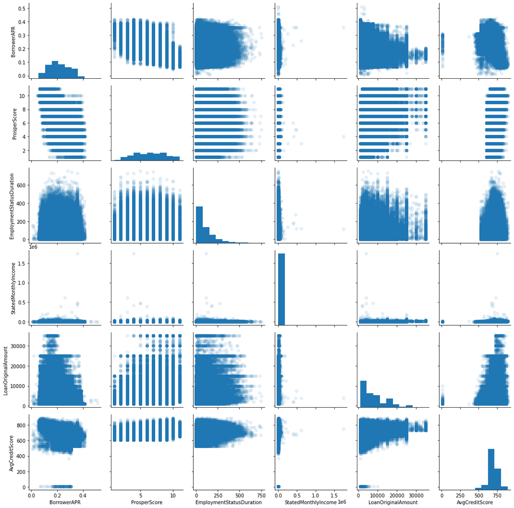

```python
g = sb.PairGrid(data=df_sub, vars = ['BorrowerAPR', 'ProsperScore', 'EmploymentStatusDuration', \
                                     'StatedMonthlyIncome', 'LoanOriginalAmount', 'AvgCreditScore'])
g.map_diag(plt.hist);
g.map_offdiag(plt.scatter, alpha=0.1);
```

### Observations

1. We can see that for StatedMonthlyIncome, there seems to be several outliers that's screwing the data making it hard to interpret.
2. Credit score ranges from 300 to 850; therfore, the data with credit score < 300 should be removed. This may be simply due to credit score not available.

I'll remove the point and make the graph again.

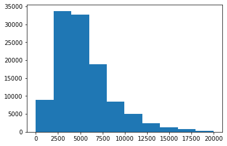

```python
plt.hist(df_sub[df_sub.StatedMonthlyIncome < 2e4].StatedMonthlyIncome);
```

Monthly income of 20000 seems like a good cutoff for the purpose of excluding outliers.

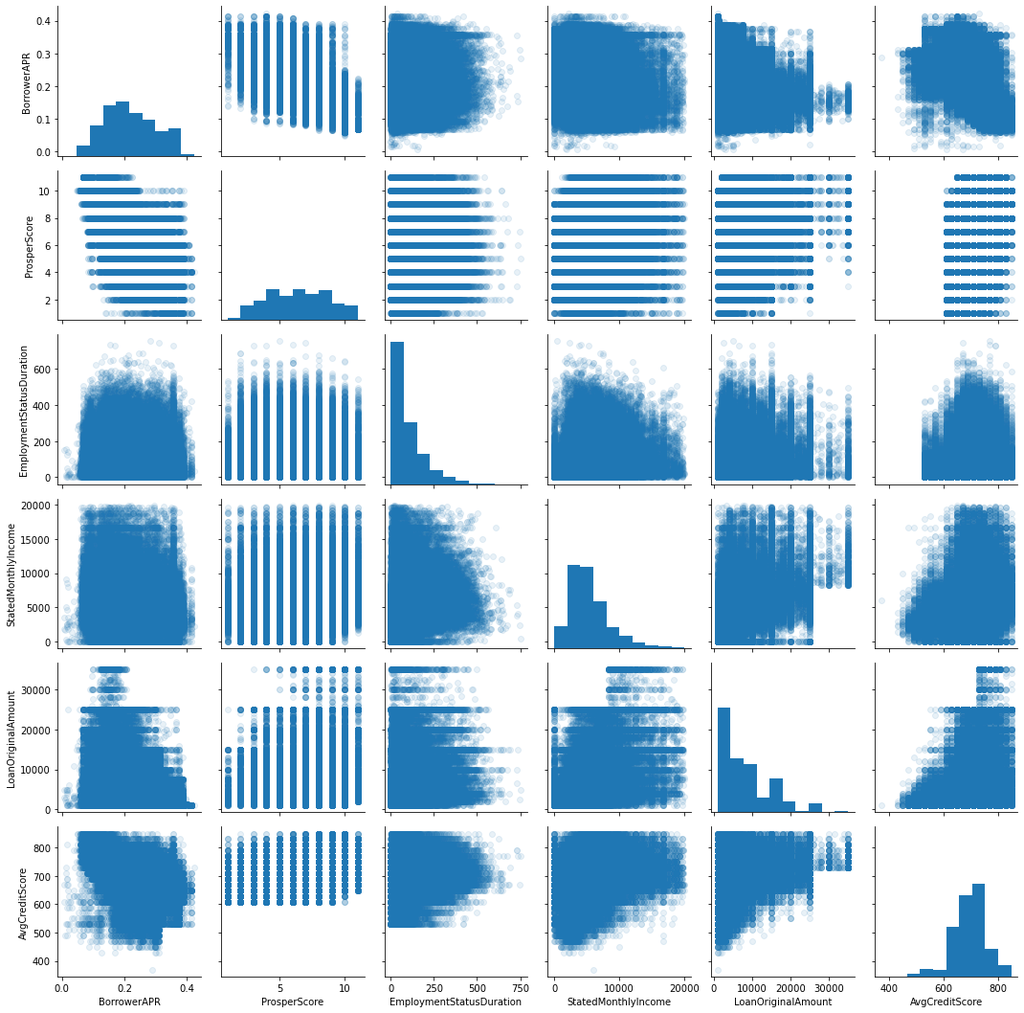

```python
g = sb.PairGrid(data=df_sub.query("AvgCreditScore >= 300 and AvgCreditScore <= 850 and StatedMonthlyIncome < 2e4"), \
                vars = ['BorrowerAPR', 'ProsperScore', 'EmploymentStatusDuration', 'StatedMonthlyIncome', 'LoanOriginalAmount', 'AvgCreditScore'])
g.map_diag(plt.hist);
g.map_offdiag(plt.scatter, alpha=0.1);
```

Some interesting trends of APR and credit score, prosper score will be discussed further below.

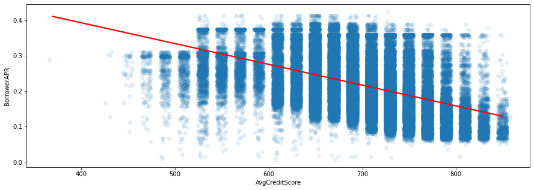

```python
figure = plt.figure(figsize=(15, 5));
sb.regplot(x='AvgCreditScore', y='BorrowerAPR',\
           data=df_sub.query("AvgCreditScore >= 300 and AvgCreditScore <= 850 and StatedMonthlyIncome < 2e4"),\
                x_jitter=5, scatter_kws={'alpha':0.1}, line_kws={'color': 'red'});
```

APR of a loan seems to be trending negatively with credit score.

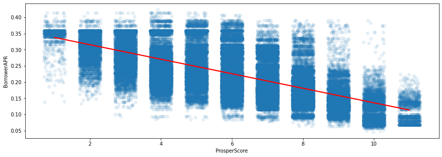

```python
figure = plt.figure(figsize=(15, 5));
sb.regplot(x='ProsperScore', y='BorrowerAPR',\
           data=df_sub.query("AvgCreditScore >= 300 and AvgCreditScore <= 850 and StatedMonthlyIncome < 2e4"),\
                x_jitter=0.3, scatter_kws={'alpha':0.1}, line_kws={'color': 'red'});
```

APR of a loan seems to be trending negatively with prosper score as well.

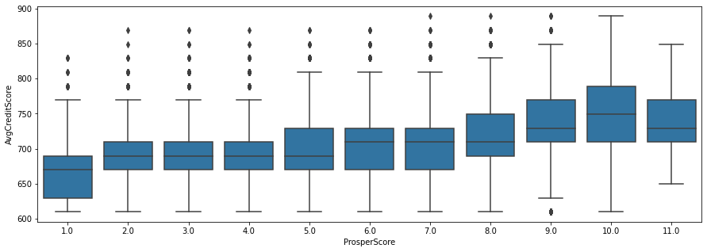

```python
base_color = sb.color_palette()[0]
figure = plt.figure(figsize=(15, 5));
sb.boxplot(x='ProsperScore', y='AvgCreditScore', data=df_sub, color=base_color);
```

Credit score and prosper score seems to correlate positively with each other; although it's noticible that the credit score of people with prosper score of 11 is lower than those with prosper score of 10.

I'll look deeper into how BorrowerAPR correlates with other categorial variables such as CreditGrade, Term, ListingCategory (numeric), and EmploymentStatus

```python
# Function for creating orders to categorical varibles.
def x_cat_order(order_list, column, data):
    '''order_list -> the list that you wish the order of the variable to be
        column -> string, the categorical column name of interest
        data -> the dataframe of interest'''
    order = pd.api.types.CategoricalDtype(ordered=True, categories=order_list)
    data[column] = data[column].astype(order)
```

Created a function to avoid repetitive code for sorting x axis variables in charts below.

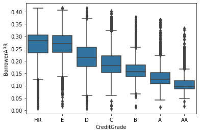

```python
credit_grade_order = ['HR', 'E', 'D', 'C', 'B', 'A', 'AA']
x_cat_order(credit_grade_order, 'CreditGrade', df_sub)
base_color = sb.color_palette()[0]
sb.boxplot(x='CreditGrade', y='BorrowerAPR',\
           data=df_sub.query("AvgCreditScore >= 300 and AvgCreditScore <= 850 and StatedMonthlyIncome < 2e4"),\
          color=base_color);
```

It shows that with higher credit grade, the APR of the loan is generally lower.

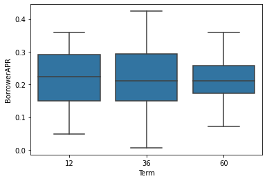

```python
term_order = [12, 36, 60]
x_cat_order(term_order, 'Term', df_sub)
base_color = sb.color_palette()[0]
sb.boxplot(x='Term', y='BorrowerAPR',\
           data=df_sub.query("AvgCreditScore >= 300 and AvgCreditScore <= 850 and StatedMonthlyIncome < 2e4"),\
          color=base_color);
```

It shows that the APR does not have clear correlation with the term of the loan.

```python
sorted(df_sub['ListingCategory (numeric)'].unique())
```

```
[0, 1, 2, 3, 4, 5, 6, 7, 8, 9, 10, 11, 12, 13, 14, 15, 16, 17, 18, 19, 20]
```

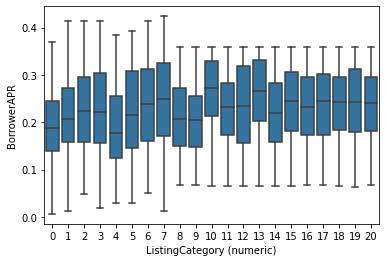

```python
list_cat_order = [0, 1, 2, 3, 4, 5, 6, 7, 8, 9, 10, 11, 12, 13, 14, 15, 16, 17, 18, 19, 20]
x_cat_order(list_cat_order, 'ListingCategory (numeric)', df_sub)
base_color = sb.color_palette()[0]
sb.boxplot(x='ListingCategory (numeric)', y='BorrowerAPR',\
           data=df_sub.query("AvgCreditScore >= 300 and AvgCreditScore <= 850 and StatedMonthlyIncome < 2e4"),\
          color=base_color);
```

The category of the listing that the borrower selected when posting their listing: 0 - Not Available, 1 - Debt Consolidation, 2 - Home Improvement, 3 - Business, 4 - Personal Loan, 5 - Student Use, 6 - Auto, 7- Other, 8 - Baby&Adoption, 9 - Boat, 10 - Cosmetic Procedure, 11 - Engagement Ring, 12 - Green Loans, 13 - Household Expenses, 14 - Large Purchases, 15 - Medical/Dental, 16 - Motorcycle, 17 - RV, 18 - Taxes, 19 - Vacation, 20 - Wedding Loans

It seems the APR of categories 0-7 has significantly higher variable than other categories. Further investigation needed to know the reason behind it.

```python
df_sub['EmploymentStatus'].unique()
```

```
array(['Self-employed', 'Employed', 'Not available', 'Full-time', 'Other',
       nan, 'Not employed', 'Part-time', 'Retired'], dtype=object)
```

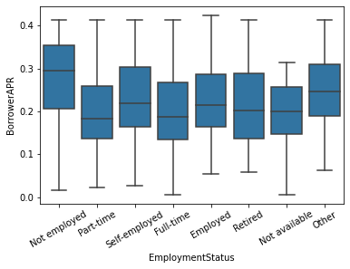

```python
emp_status_order = ['Not employed', 'Part-time', 'Self-employed', 'Full-time', 'Employed', 'Retired', 'Not available',  'Other']
x_cat_order(emp_status_order, 'EmploymentStatus', df_sub)
base_color = sb.color_palette()[0]
sb.boxplot(x='EmploymentStatus', y='BorrowerAPR',\
           data=df_sub.query("AvgCreditScore >= 300 and AvgCreditScore <= 850 and StatedMonthlyIncome < 2e4"),\
          color=base_color);
plt.xticks(rotation=30);
```

People woking full-time were able to get lower APRs, and people not employed were getting highest APR in average as expected. Also, we can see that self-employed people are gerring higer APR than full-time, part-time, and retired people which is quite interesting.

# Multivariable Exploration

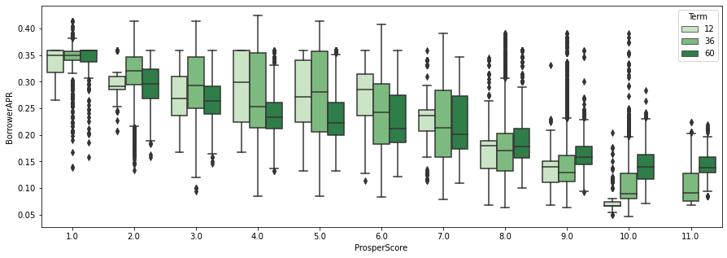

```python
figure = plt.figure(figsize=(15, 5));
sb.boxplot(x='ProsperScore', y='BorrowerAPR',\
           data=df_sub, hue='Term', palette='Greens');
```

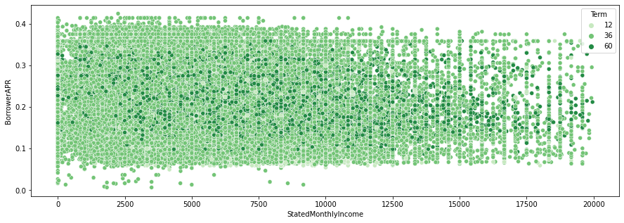

```python
figure = plt.figure(figsize=(15, 5));
sb.scatterplot(x='StatedMonthlyIncome', y='BorrowerAPR',\
           data=df_sub.query("AvgCreditScore >= 300 and AvgCreditScore <= 850 and StatedMonthlyIncome < 2e4"),\
               hue='Term', palette='Greens');
```

The variable of 36 month loan APR is greater than that of 60 month loan and 12 month loan. Maybe it's just because there were a lot more 36 month loan than 12 and 60 month loan.

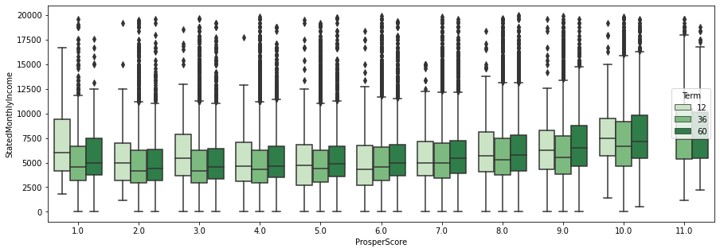

```python
figure = plt.figure(figsize=(15, 5));
sb.boxplot(x='ProsperScore', y='StatedMonthlyIncome',\
           data=df_sub.query("AvgCreditScore >= 300 and AvgCreditScore <= 850 and StatedMonthlyIncome < 2e4"), \
           hue='Term', palette='Greens');
```

Borrowers with higher prosper score also have higher income. There's no clear correlation between the term of loan and monthly income.

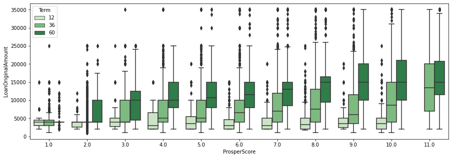

```python
figure = plt.figure(figsize=(15, 5));
sb.boxplot(x='ProsperScore', y='LoanOriginalAmount',\
           data=df_sub.query("AvgCreditScore >= 300 and AvgCreditScore <= 850 and StatedMonthlyIncome < 2e4"), \
           hue='Term', palette='Greens');
```

The loan amount increases as term increases which makes sense.

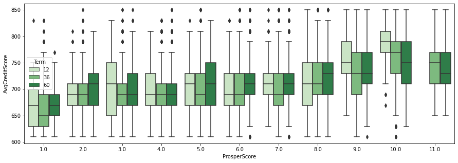

```python
figure = plt.figure(figsize=(15, 5));
sb.boxplot(x='ProsperScore', y='AvgCreditScore',\
           data=df_sub.query("AvgCreditScore >= 300 and AvgCreditScore <= 850 and StatedMonthlyIncome < 2e4"), \
           hue='Term', palette='Greens');
```

Average credit score trends positively with prosper score which makes sense, and does not correlate with the term of loans that the borrower applied for.

## Key Observations

1. Credit grade, credit score, and prosper score of borrowers follow similar trend of unimodal distribution that most people are in the middle of the scale.
2. 36 Month loan is the most popular followed by 60 month, and least people take out 12 month loan.
3. The most popular reason of applying for a loan is for debt consolidation.
4. Most borrowers are employed.
5. The most important factors determining the APR of a loan is credit score, prosper score, credit grade, and employment status. If we assume that credit score is an important factor in determining prospoer score and credit grade, APR can be mostly determined from credit score and employment status.